# Modelowanie decyzji kredytowych przy użyciu uczenia maszynowego i selekcji cech

Szymon Sergiel

2025-05-24

# Zdefiniowanie problemu predykcyjnego oraz scharakteryzowanie analizowanego zbioru danych

Celem projektu jest zbudowanie modelu predykcyjnego, który na podstawie cech związanych z pożyczkobiorcą oraz parametrami wniosku kredytowego będzie przewidywał zmienną status – czyli, czy pożyczka zostanie zaakceptowana (1), czy odrzucona (0).

To jest klasyczny problem klasyfikacji binarnej, w którym celem jest nauczenie modelu rozpoznawania wzorców decyzyjnych na podstawie dostępnych danych wejściowych.

## Opis zmiennych

### 1. Identyfikacyjne i ogólne:

X - Numer porządkowy rekordu

id - Unikalny identyfikator klienta lub wniosku

year - Rok złożenia wniosku kredytowego

### 2. Informacje o kredycie:

loan_limit - Limit kredytowy (np. standardowy, przekroczony)

loan_type - Rodzaj pożyczki

loan_purpose - Cel pożyczki (np. zakup domu, refinansowanie)

loan_amount - Kwota wnioskowanego kredytu

rate_of_interest - Oprocentowanie nominalne kredytu

interest_rate_spread - Różnica między oprocentowaniem a średnią rynkową

upfront_charges - Opłaty początkowe (prowizje, opłaty manipulacyjne)

term - Okres spłaty kredytu (w miesiącach, np. 360 dni)

secured_by - Forma zabezpieczenia kredytu (np. dom)

security_type - Rodzaj zabezpieczenia (np. bezpośrednie, pośrednie)

submission_of_application - Kanał złożenia wniosku (np. online, instytucja)

ltv (Loan-to-Value) - Stosunek kwoty kredytu do wartości zabezpieczenia

### 3. Informacje o wniosku i strukturze kredytu:

approv_in_adv - Czy kredyt został zatwierdzony wstępnie

business_or_commercial - Czy wniosek dotyczył działalności gospodarczej

neg_amortization - Czy zastosowano negatywną amortyzację

interest_only - Czy spłaty obejmują tylko odsetki

lump_sum_payment - Czy planowana była płatność jednorazowa

### 4. Informacje o nieruchomości:

property_value - Wartość nieruchomości

construction_type - Typ konstrukcji (np. SB – stick built)

occupancy_type - Sposób zamieszkania (np. właściciel, najemca)

total_units - Liczba jednostek mieszkalnych

### 5. Dane demograficzne klienta:

gender - Płeć klienta

income - Dochód klienta

credit_score - Ocena zdolności kredytowej

credit_type - Rodzaj historii kredytowej

co.applicant_credit_type -Typ kredytu współwnioskodawcy

age - Przedział wiekowy klienta

region - Region geograficzny

### 6. Zmienne pomocnicze / pochodne:

status - Zmienna celu: 0 = odrzucona pożyczka, 1 = zatwierdzona

high_interest_rate - Czy oprocentowanie przekracza ustalony próg

senior_age - Czy klient jest seniorem (0/1)

dti.r1 - Wskaźnik zadłużenia do dochodu (debt-to-income ratio)

open_credit - Dostęp do otwartych linii kredytowych

credit_worthiness - Ocena wiarygodności kredytowej

# Czyszczenie danych oraz wstępna selekcja cech

Usunięcie zmiennych “interest_rate_spread” oraz “upfront_charges” zostało przeprowadzone na wczesnym etapie, ponieważ zawierają one brakujące wartości wyłącznie dla obserwacji, w których zmienna docelowa status przyjmuje wartość 1. Oznacza to, że obecność braku danych w tych kolumnach jest silnie skorelowana z klasą wyjściową, co może prowadzić do nadmiernego dopasowania modelu (overfittingu). Zamiast dostarczać rzeczywistej informacji o przypadku, model mógłby nauczyć się rozpoznawać klasę wyłącznie na podstawie obecności lub braku danych. Dlatego, aby uniknąć tego efektu i zapewnić bardziej rzetelny proces selekcji cech oraz późniejsze modelowanie, zdecydowałem się na usunięcie tych zmiennych na samym początku analizy.

```r
dane <- dane %>%
  select(-c("interest_rate_spread","upfront_charges"))
```

## Podział na zbiór testowy i treningowy

```r
dane <- na.omit(dane)
set.seed(2025)

split1 <- initial_split(dane, prop = 0.8)

Train_Original1 <- training(split1)
Test_Original1 <- testing(split1)
```

## Konwertowanie zmiennych tesktowych na kategoryczne a następnie zamiana wszystkich zmiennych na numeryczne

```r
Test_Original1 <- Test_Original1 %>%
  mutate(across(where(is.character), as.factor))
Test_Original1$status <- as.factor(Test_Original1$status)
Test_Original1 <- data.frame(sapply(Test_Original1, as.numeric))
Test_Original1 <- Test_Original1 %>%
  mutate(across(c(loan_limit,gender,approv_in_adv,loan_type,loan_purpose,credit_worthiness,open_credit,business_or_commercial,
                  neg_ammortization,interest_only,occupancy_type,secured_by,
                  total_units,credit_type,co.applicant_credit_type,age,submission_of_application,
                  security_type,status,high_interest_rate,senior_age),as.factor))
levels(Test_Original1$status) <- c("0", "1")

Train_Original1 <- Train_Original1 %>%
  mutate(across(where(is.character), as.factor))
Train_Original1$status <- as.factor(Train_Original1$status)
Train_Original1 <- data.frame(sapply(Train_Original1, as.numeric))
Train_Original1 <- Train_Original1%>%
  mutate(across(c(loan_limit,gender,approv_in_adv,loan_type,loan_purpose,credit_worthiness,open_credit,business_or_commercial,
                  neg_ammortization,interest_only,occupancy_type,secured_by,
                  total_units,credit_type,co.applicant_credit_type,age,submission_of_application,
                  security_type,status,high_interest_rate,senior_age),as.factor))
levels(Train_Original1$status) <- c("0", "1")
```

Polecenie levels() <- c(“0”, “1”) zostało użyte w celu jawnego ustawienia poziomów (levels) zmiennej status jako “0” i “1”, które odpowiadają klasom w zadaniu klasyfikacyjnym ponieważ po konwersji zmiennej na typ factor, R domyślnie przypisuje poziomy jako “1”, “2” lub w kolejności alfabetycznej nazw, co może nie odzwierciedlać właściwej semantyki danych.

## Future select (Boruta)

Do selekcji cech wykorzystałem algorytm Boruta, ponieważ jest to zaawansowana metoda oparta na Random Forest, która automatycznie ocenia, które zmienne są istotne dla przewidywania zmiennej celu (status) oraz najlepiej działa na duże zbiory tak jak w tym przypaku. Boruta działa poprzez tworzenie tzw. cech losowych (shadow features), a następnie porównuje znaczenie każdej rzeczywistej zmiennej do tych sztucznie wygenerowanych. Zmienna uznana zostaje za istotną tylko wtedy, gdy jej znaczenie istotnie przekracza znaczenie najlepszej z cech losowych.

Dzięki temu Boruta:

- wybiera tylko rzeczywiście istotne zmienne (nie pomija słabych, ale ważnych cech).
- redukuje ryzyko overfittingu, eliminując szum informacyjny.
- pozwala zwiększyć dokładność i wydajność modeli predykcyjnych.

Selekcję cech wykonano wyłącznie na zbiorze treningowym, ponieważ:

- W procesie modelowania musimy unikać wycieku danych (data leakage) — czyli sytuacji, gdy informacje z danych testowych wpływają na proces uczenia model.
- Zbiór testowy powinien być traktowany jako całkowicie nieznany modelowi, by móc rzetelnie ocenić jego skuteczność na nowych danyc.

```r
boruta_result <- readRDS("boruta_result.rds")

print(boruta_result)
```

```
## Boruta performed 20 iterations in 35.21659 mins.
##  31 attributes confirmed important: age, approv_in_adv,
## business_or_commercial, co.applicant_credit_type, construction_type and
## 26 more;
##  3 attributes confirmed unimportant: credit_score, credit_type, year;
```

```r
getSelectedAttributes(boruta_result, withTentative = FALSE)
```

```
##  [1] "X"                         "id"
##  [3] "loan_limit"                "gender"
##  [5] "approv_in_adv"             "loan_type"
##  [7] "loan_purpose"              "credit_worthiness"
##  [9] "open_credit"               "business_or_commercial"
## [11] "loan_amount"               "rate_of_interest"
## [13] "term"                      "neg_ammortization"
## [15] "interest_only"             "lump_sum_payment"
## [17] "property_value"            "construction_type"
## [19] "occupancy_type"            "secured_by"
## [21] "total_units"               "income"
## [23] "co.applicant_credit_type"  "age"
## [25] "submission_of_application" "ltv"
## [27] "region"                    "security_type"
## [29] "dtir1"                     "high_interest_rate"
## [31] "senior_age"
```

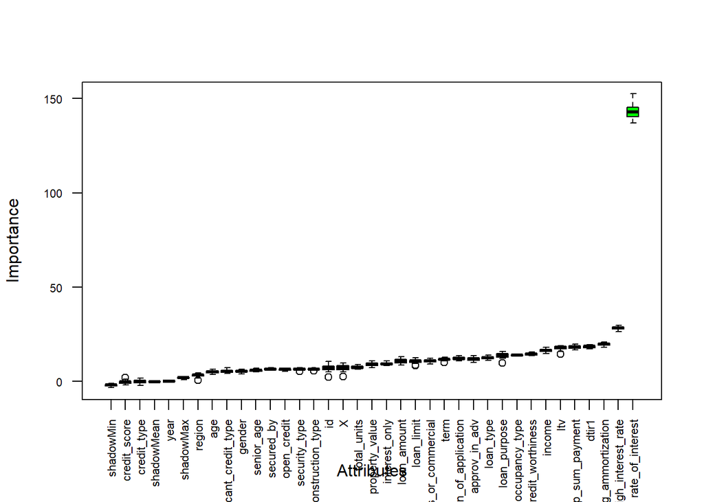

```r
plot(boruta_result, las = 2, cex.axis = 0.7)
```

Na podstawie analizy algorytmu Boruta:

- Trzy zmienne zostały jednoznacznie zaklasyfikowane jako nieistotne: credit_score, credit_type, year.Ich znaczenie było niższe niż cech losowych tzw. shadow features), co wskazuje na brak przydatności w predykcji.
- Zmienna rate_of_interest, mimo że uzyskała bardzo wysoką wagę w Borucie, została świadomie usunięta z dalszej analizy.

Decyzja o usunięciu rate_of_interest wynika z faktu, że zmienna ta:

- Jest silnie skorelowana ze zmienną docelową (status),
- Może prowadzić do overfittingu modelu — nienaturalnie wysokich wyników na zbiorze testowym,
- Wskazuje na obecność data leakage – czyli wycieku informacji z przyszłości do modelu (model zna dane, które w rzeczywistości nie powinny być dostępne w momencie predykcji).

Dlatego, pomimo wysokiego znaczenia tej zmiennej według Boruty, została ona celowo wykluczona, by zwiększyć rzetelność i ogólność budowanych modeli predykcyjnych.

```r
#Czyszczenie zbioru danych
Train_Original1<- Train_Original1 %>%
  select(-c("credit_score","credit_type","year","rate_of_interest"))
Test_Original1<- Test_Original1 %>%
  select(-c("credit_score","credit_type","year","rate_of_interest"))
```

# Wizualizacja istotnych zależności w analizowanym zbiorze danych

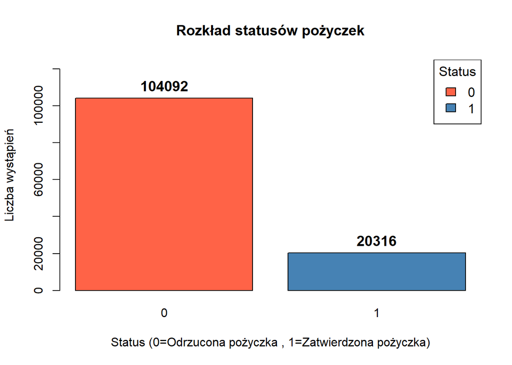

Z wykresu wyraźnie wynika, że zbiór danych jest silnie niezbalansowany, ponieważ liczba obserwacji w klasie 0 (odrzuconej pożyczki) jest ponad pięciokrotnie wyższa niż w klasie 1 (zatwierdzonej pożyczki). Taki brak równowagi może negatywnie wpływać na skuteczność modeli klasyfikacyjnych

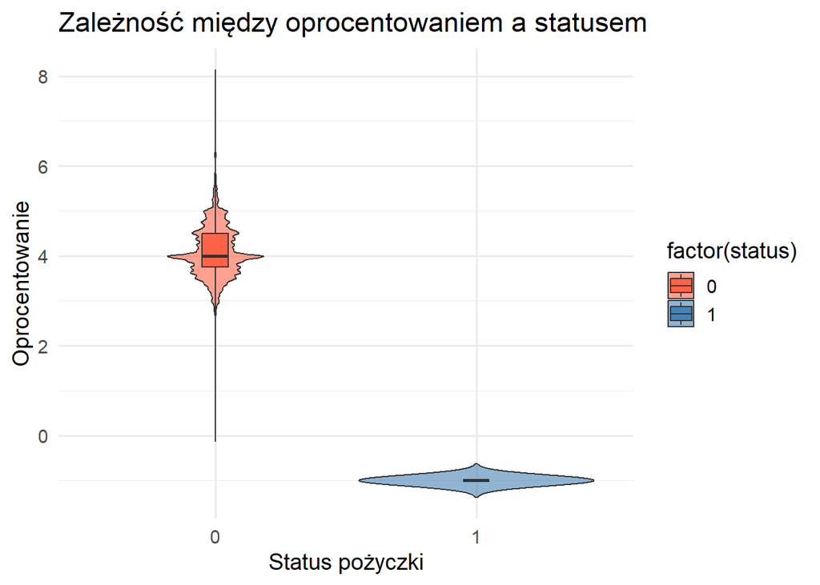

Tak silna i jednoznaczna zależność między oprocentowaniem a statusem pożyczki wskazuje na zjawisko data leakage. Z tego względu, mimo silnej zależności, zmienna rate_of_interest została usunięta aby uniknąć nieuczciwego dopasowania modelu oraz zachować jego użyteczność i generalizację na danych rzeczywistych.

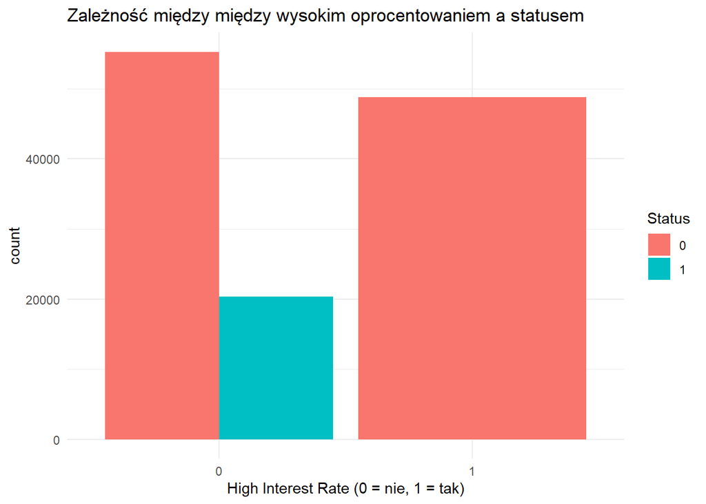

Na wykresie przedstawiono zależność między zmienną binarną high_interest_rate a zmienną docelową status (0 = odrzucona pożyczka, 1 = zatwierdzona pożyczka). Zmienna high_interest_rate informuje, czy dana pożyczka została zakwalifikowana jako posiadająca wysokie oprocentowanie.

Analizując wykres, możemy zaobserwować, że:

- Gdy high_interest_rate = 0 (oprocentowanie nie jest wysokie), pojawia się zarówno duża liczba zatwierdzonych, jak i odrzuconych wniosków, choć dominują odrzucenia.
- Gdy high_interest_rate = 1 (wysokie oprocentowanie), wszystkie wnioski kończą się odrzuceniem pożyczki.

W przeprowadzonej analizie istotności cech (m.in. przy użyciu algorytmu Boruta) zmienna high_interest_rate została zaklasyfikowana jako jedna z najistotniejszych zmiennych wpływających na wynik decyzji kredytowej — zaraz po rate_of_interest. Jej silna zależność ze zmienną docelową sugeruje, że banki bardzo często odrzucają wnioski o kredyt, jeżeli przewidywane oprocentowanie jest wysokie.

# Przygotowanie danych do dalszego procesu modelowania

```r
recipe_original1 <- recipe(status ~ ., data = Train_Original1) %>%
  step_normalize(all_numeric_predictors()) %>%
  step_dummy(all_nominal_predictors())

prep_recipe_original1 <- prep(recipe_original1)
Train_Original1 <- bake(prep_recipe_original1, new_data = NULL)
Test_Original1 <- bake(prep_recipe_original1, new_data = Test_Original1)
```

## Undersampling

```r
Train_0 <- Train_Original1 %>% filter(status == 0)
Train_1 <- Train_Original1 %>% filter(status == 1)
Train_0_sample <- Train_0 %>% sample_n(nrow(Train_1))
Train_bal <- bind_rows(Train_0_sample, Train_1)
table(Train_bal$status)
```

```
##
##     0     1
## 16248 16248
```

Z uwagi na silną niezbalansowaną strukturę klas (przewaga klasy 0 — odrzuconych wniosków kredytowych), zastosowałem undersampling na zbiorze treningowym. Celem było:

- zwiększenie równowagi klas,
- umożliwienie lepszego nauczenia się wzorców dla rzadziej występującej klasy 1.

Undersampling wykonano wyłącznie na zbiorze treningowym, aby nie zafałszowywać wyników ewaluacyjnych na zbiorze testowym.

# Eksploracja danych z użyciem technik uczenia maszynowego

W celu rozwiązania problemu klasyfikacji statusu pożyczki (status) zbudowano dwa modele uczenia maszynowego:

Regresja logistyczna (Logistic Regression) — klasyczny, liniowy model służący do klasyfikacji binarnej.

Random Forest (Las losowy) — model oparty na zbiorze drzew decyzyjnych, który dobrze radzi sobie z problemem nieliniowości oraz interakcji pomiędzy zmiennymi.

Dwa warianty analizy:

Aby dokładniej ocenić wydajność modeli oraz wpływ niezbalansowania danych, modele zostały wytrenowane i przetestowane na dwóch wariantach zbioru danych:

1️⃣ Na oryginalnym zbiorze treningowym (dane niezbalansowane):

Status 0 (odrzucone pożyczki) stanowi około 83%,

Status 1 (zaakceptowane pożyczki) stanowi około 17%.

2️⃣ Na zbiorze po zastosowaniu undersamplingu:

Liczba przykładów z klasy dominującej została losowo zredukowana w celu wyrównania proporcji klas.

Zbalansowanie klas pozwala lepiej ocenić zdolność modeli do rozpoznawania klasy mniejszościowej.

### Regresja Logistyczna

```r
logistic_regression1 <- logistic_reg() %>%
  set_engine("glm") %>%
  set_mode("classification")

logistic_regression_fitting1 <- fit(logistic_regression1, status ~ .,
                                   data = Train_Original1)
Train_Preds <- predict(logistic_regression_fitting1, Train_Original1,
                       type = "prob") %>%
  bind_cols(predict(logistic_regression_fitting1, Train_Original1)) %>%
  bind_cols(Train_Original1 %>% select(status))

Test_Preds <- predict(logistic_regression_fitting1, Test_Original1,
                       type = "prob") %>%
  bind_cols(predict(logistic_regression_fitting1, Test_Original1)) %>%
  bind_cols(Test_Original1 %>% select(status))

train_conf <- conf_mat(Train_Preds, truth = status, estimate = .pred_class)
test_conf <- conf_mat(Test_Preds,  truth = status, estimate = .pred_class)
```

### Random Forest

```r
random_forest_model1 <- rand_forest(mode = "classification") %>%
  set_engine("ranger")


rf_fit1 <- fit(random_forest_model1, status ~ ., data = Train_Original1)


train_preds1 <- predict(rf_fit1, Train_Original1, type = "prob") %>%
  bind_cols(predict(rf_fit1, Train_Original1)) %>%
  bind_cols(Train_Original1 %>% select(status))


test_preds1 <- predict(rf_fit1, Test_Original1, type = "prob") %>%
  bind_cols(predict(rf_fit1, Test_Original1)) %>%
  bind_cols(Test_Original1 %>% select(status))


train_conf1 <- conf_mat(train_preds1, truth = status, estimate = .pred_class)
test_conf1 <- conf_mat(test_preds1,  truth = status, estimate = .pred_class)
```

### Regresja Logistyczna + Undersampling

```r
logistic_regression_fitting2 <- fit(logistic_regression1, status ~ .,
                                   data = Train_bal)


Train_Preds2 <- predict(logistic_regression_fitting2, Train_bal,
                       type = "prob") %>%
  bind_cols(predict(logistic_regression_fitting2, Train_bal)) %>%
  bind_cols(Train_bal %>% select(status))


Test_Preds2 <- predict(logistic_regression_fitting2, Test_Original1,
                       type = "prob") %>%
  bind_cols(predict(logistic_regression_fitting2, Test_Original1)) %>%
  bind_cols(Test_Original1 %>% select(status))

train_conf2 <- conf_mat(Train_Preds2, truth = status, estimate = .pred_class)
test_conf2 <- conf_mat(Test_Preds2,  truth = status, estimate = .pred_class)
```

### Random forest + Undersampling

```r
rf_fit2 <- fit(random_forest_model1, status ~ ., data = Train_bal)


train_preds2 <- predict(rf_fit2, Train_bal, type = "prob") %>%
  bind_cols(predict(rf_fit2, Train_bal)) %>%
  bind_cols(Train_bal %>% select(status))


test_preds2 <- predict(rf_fit2, Test_Original1, type = "prob") %>%
  bind_cols(predict(rf_fit2, Test_Original1)) %>%
  bind_cols(Test_Original1 %>% select(status))


train_conf3 <- conf_mat(train_preds2, truth = status, estimate = .pred_class)
test_conf3 <- conf_mat(test_preds2,  truth = status, estimate = .pred_class)
```

# Ewaluacja modeli uczenia maszynowego

### Regresja Logarytmiczna

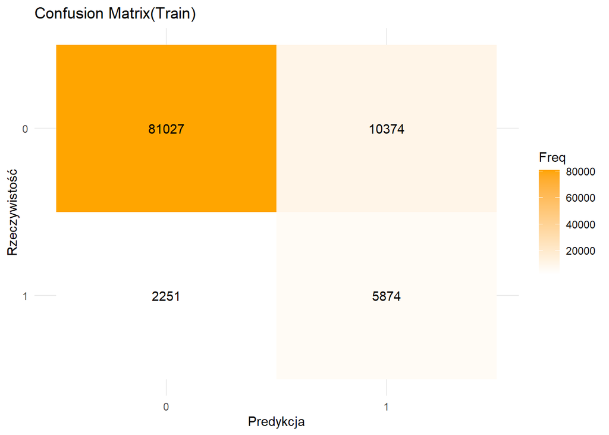

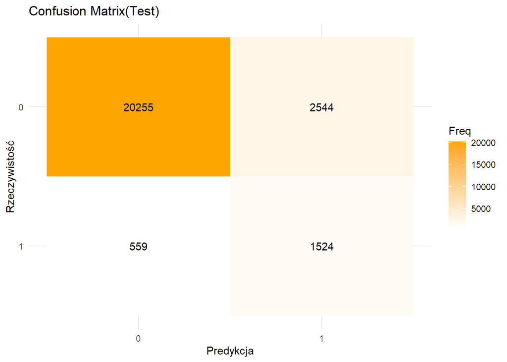

Na zbiorze treningowym model regresji logistycznej dobrze radzi sobie z klasyfikacją większości obserwacji, jednak pojawia się zauważalna liczba błędów w przypadku obydwu klas. Wyniki wskazują na umiarkowaną skuteczność modelu przy trenowaniu.

Na zbiorze testowym regresja logistyczna utrzymuje podobną jakość predykcji, poprawnie klasyfikując znaczną część wniosków, jednak pojawiają się również błędy klasyfikacyjne. Model generalizuje umiarkowanie dobrze.

### Random Forest

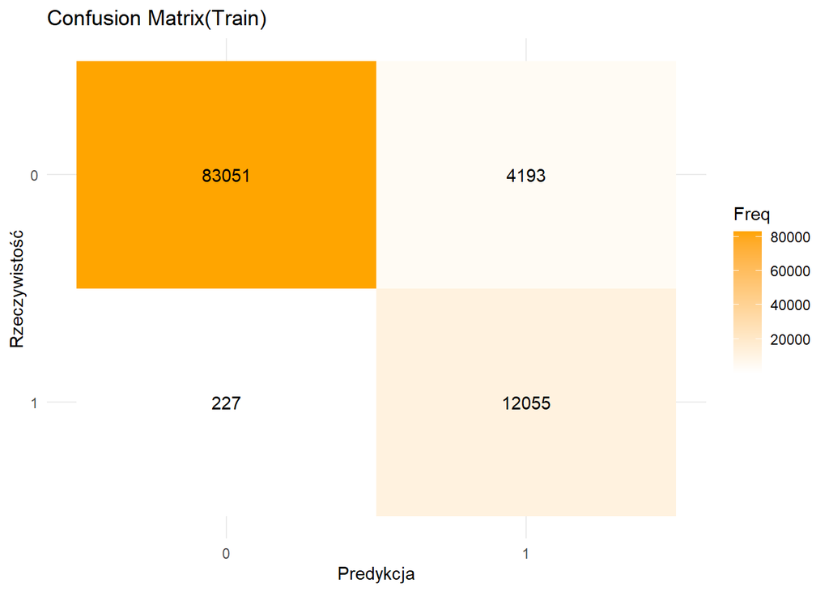

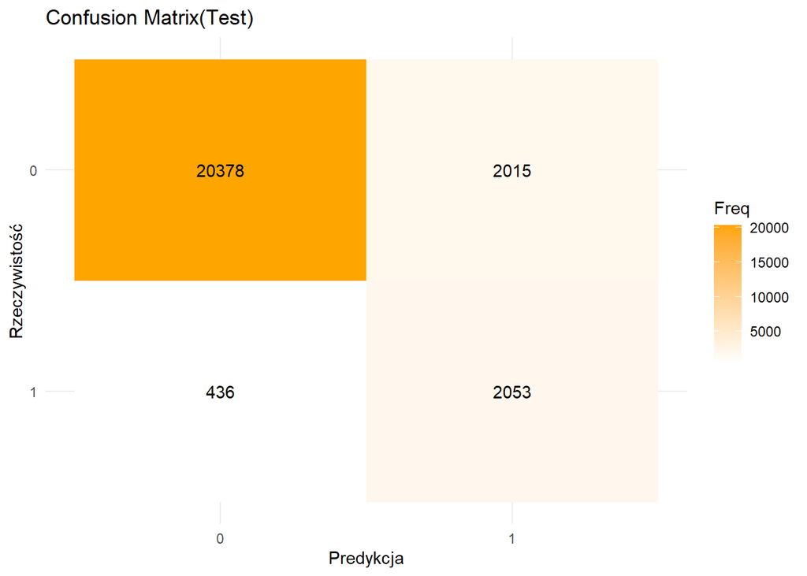

Na zbiorze treningowym model Random Forest bardzo dobrze klasyfikuje dane — liczba poprawnie sklasyfikowanych przykładów w obu klasach jest wysoka, a błędów klasyfikacyjnych jest niewiele. Może to wskazywać na bardzo dobre dopasowanie modelu do danych treningowych.

Na zbiorze testowym Random Forest osiąga wysoką skuteczność predykcji. Większość obserwacji została sklasyfikowana poprawnie w obu klasach, a liczba błędnych predykcji pozostaje niska. Model dobrze generalizuje na nowych danych.

### Regresja Logistyczna + Undersampling

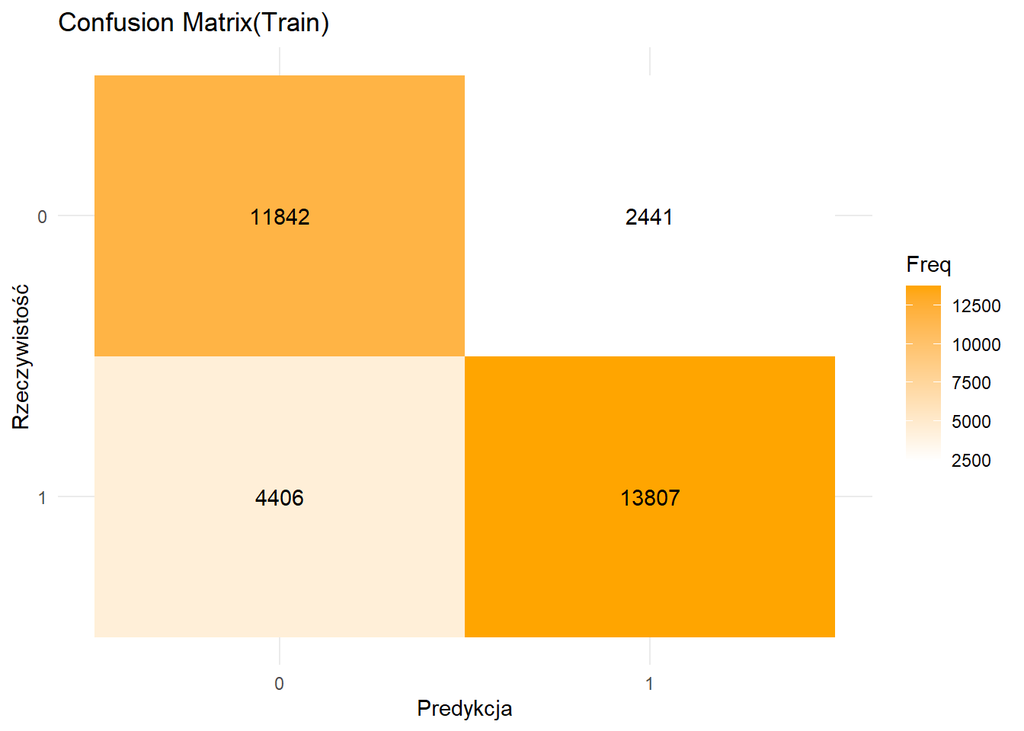

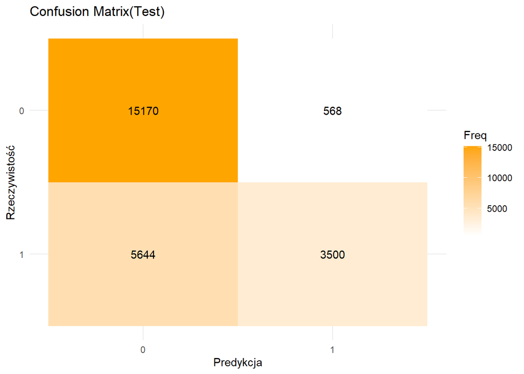

Po zastosowaniu undersamplingu na zbiorze treningowym model regresji logistycznej lepiej radzi sobie z rozpoznawaniem klasy mniejszościowej (zaakceptowanych pożyczek). Liczba poprawnych klasyfikacji dla obu klas jest bardziej zrównoważona. Model poprawnie zaklasyfikował 11 842 przypadków klasy 0 oraz 13 807 przypadków klasy 1. Nadal występują błędne predykcje, jednak wyraźnie poprawiła się czułość modelu względem klasy mniejszościowej, co pokazuje skuteczność przeprowadzonego balansu klas podczas treningu.

Natomiast na zbiorze testowym model regresji logistycznej lepiej wyważył klasyfikację obu klas, jednak ogólna skuteczność predykcji spadła w porównaniu do modelu trenowanego na pełnym, niezbalansowanym zbiorze danych. Model poprawnie klasyfikuje znaczną część przypadków zarówno w klasie większościowej, jak i mniejszościowej, jednak liczba błędnych klasyfikacji zwiększyła się. Zastosowanie undersamplingu pozwoliło ograniczyć silną dominację klasy większościowej, kosztem nieco mniejszej precyzji ogólnej.

### Random forest + Undersampling

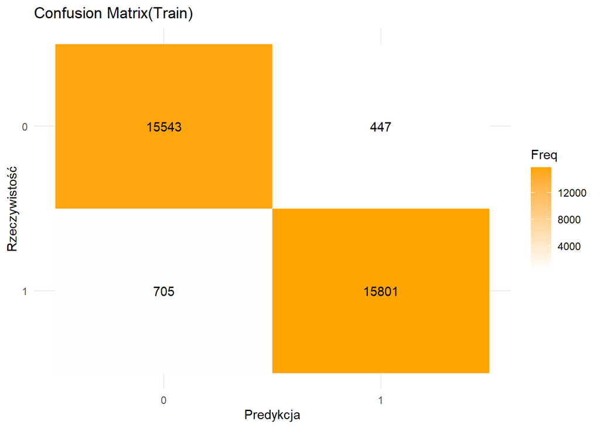

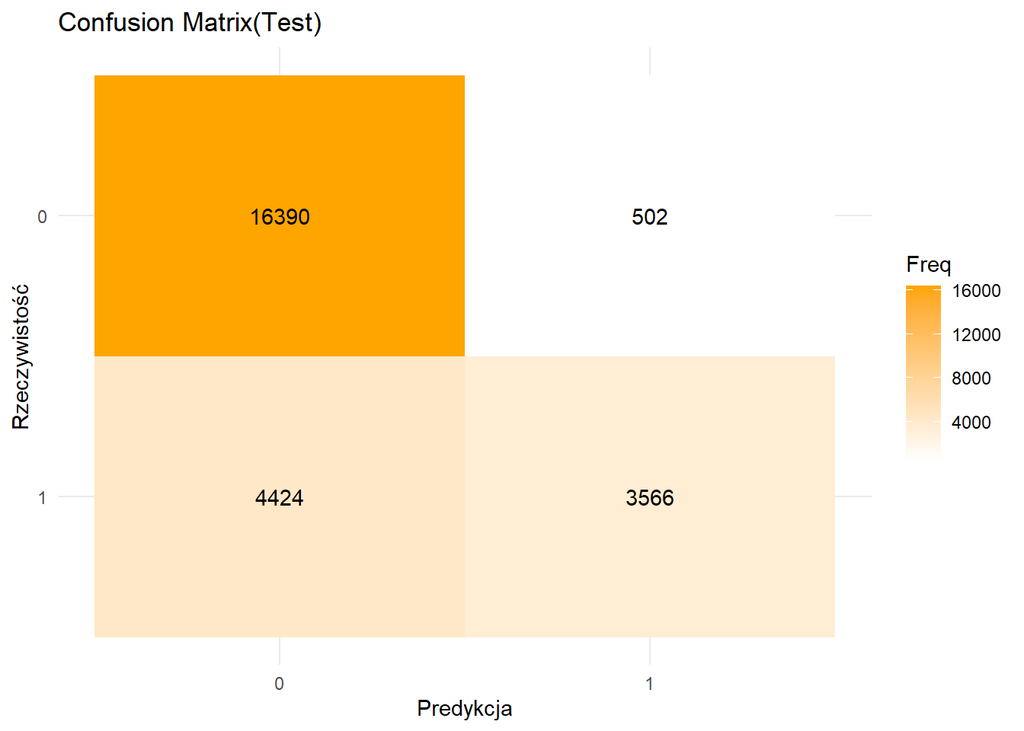

Model Random Forest po zastosowaniu undersamplingu bardzo dobrze poradził sobie z klasyfikacją zarówno klasy większościowej, jak i mniejszościowej na zbiorze treningowym. Liczba błędnych klasyfikacji jest niewielka w obu klasach, co sugeruje bardzo dobrą jakość dopasowania modelu do danych treningowych.

|  | Metric | Train_LR | Train_RF | Train_LR + US | Train_RF + US | Test_LR | Test_RF | Test_LR + US | Test_RF + US |
| --- | --- | --- | --- | --- | --- | --- | --- | --- | --- |
| 1 | Accuracy | 0.873 | 0.956 | 0.789 | 0.965 | 0.875 | 0.901 | 0.75 | 0.802 |
| 2 | Precision | 0.887 | 0.952 | 0.829 | 0.972 | 0.888 | 0.91 | 0.964 | 0.97 |
| 3 | Recall | 0.973 | 0.997 | 0.729 | 0.957 | 0.973 | 0.979 | 0.729 | 0.787 |
| 4 | F1-score | 0.928 | 0.974 | 0.776 | 0.964 | 0.929 | 0.943 | 0.83 | 0.869 |

W analizie porównano cztery podejścia modelowania:

LR (Logistic Regression) na pełnym zbiorze danych,

RF (Random Forest) na pełnym zbiorze danych,

LR + US (Logistic Regression z undersamplingiem),

RF + US (Random Forest z undersamplingiem).

Ocenę modeli przeprowadzono na zbiorze treningowym oraz testowym przy użyciu czterech podstawowych metryk: Accuracy, Precision, Recall, F1-score.

### Logistic Regression (pełny zbiór danych)

- Train: Accuracy = 0.873, Precision = 0.887, Recall = 0.973, F1 = 0.928

Model regresji logistycznej osiągnął bardzo dobre wyniki na zbiorze treningowym. Szczególnie wysoki poziom recall (0.973) wskazuje, że model skutecznie identyfikuje niemal wszystkie pozytywne przypadki, co jest istotne np. w kontekście wykrywania klientów z ryzykiem niewypłacalności. Wysoka precyzja (0.887) oznacza natomiast, że wśród przewidywanych przypadków pozytywnych niewiele jest błędnych klasyfikacji.

- Test: Accuracy = 0.875, Precision = 0.888, Recall = 0.973, F1 = 0.929

Wyniki na zbiorze testowym są bardzo zbliżone do wyników treningowych. Świadczy to o dobrej generalizacji modelu — nie występuje tu istotny problem przeuczenia ani niedouczenia. Regresja logistyczna sprawdza się więc bardzo stabilnie w predykcji na nowych danych.

### Random Forest (pełny zbiór danych)

- Train: Accuracy = 0.956, Precision = 0.952, Recall = 0.997, F1 = 0.974

Random Forest osiągnął bardzo wysoką skuteczność na danych treningowych, niemal perfekcyjnie rozpoznając pozytywne przypadki (recall 0.997). Bardzo wysoka precyzja i accuracy pokazują, że model jest w stanie efektywnie rozróżniać między klasami i nie generuje wielu błędnych klasyfikacji.

- Test: Accuracy = 0.901, Precision = 0.910, Recall = 0.979, F1 = 0.943

Na zbiorze testowym wyniki są tylko nieznacznie niższe niż na treningowym, co oznacza, że model generalizuje bardzo dobrze mimo swojej dużej złożoności. Random Forest na pełnym zbiorze danych wykazuje dużą odporność na przeuczenie w tym przypadku.

### Logistic Regression z undersamplingiem

- Train: Accuracy = 0.789, Precision = 0.829, Recall = 0.729, F1 = 0.776

Po zastosowaniu undersamplingu regresja logistyczna nieco słabiej dopasowuje się do danych treningowych (accuracy spadło do 0.789), co jest naturalne — zmniejszyliśmy ilość danych klasy dominującej.

- Test: Accuracy = 0.750, Precision = 0.964, Recall = 0.729, F1 = 0.830

Na zbiorze testowym model utrzymuje wysoką precyzję (0.964), czyli rzadko myli klasy pozytywne, ale recall spada (0.729), co oznacza, że nie wszystkie przypadki pozytywne są wychwytywane. Model nie wykazuje jednak przeuczenia — metryki są spójne między zbiorem treningowym i testowym. Widać natomiast, że undersampling znacząco wpłynął na obniżenie czułości modelu.

### Random Forest z undersamplingiem

- Train: Accuracy = 0.965, Precision = 0.972, Recall = 0.957, F1 = 0.964

Model Random Forest po zastosowaniu undersamplingu osiąga bardzo wysokie wyniki na danych treningowych, praktycznie perfekcyjnie klasyfikując przypadki. Jednak tak dobre wyniki na train mogą sugerować przeuczenie — model może być “przyzwyczajony” do rozkładu klas, który stworzyliśmy przez undersampling.

- Test: Accuracy = 0.802, Precision = 0.970, Recall = 0.787, F1 = 0.869

Na zbiorze testowym następuje już wyraźne pogorszenie skuteczności (accuracy spada z 0.965 na train do 0.802 na test). Wysoka precyzja (0.970) świadczy o tym, że jeśli model już przewiduje klasę pozytywną, to robi to trafnie, natomiast recall (0.787) pokazuje, że pewną część pozytywnych przypadków pomija. Tak znaczny spadek accuracy wskazuje na częściowe przeuczenie modelu po zastosowaniu undersamplingu, szczególnie w przypadku bardziej złożonego algorytmu Random Forest.

# Podsumowanie i Wnioski

W projekcie przeanalizowano dane dotyczące przyznawania pożyczek, których głównym celem była predykcja zmiennej status, informującej o zatwierdzeniu lub odrzuceniu wniosku pożyczkowego.

Wstępne czyszczenie danych pozwoliło zidentyfikować dwie zmienne (interest_rate_spread oraz upfront_charges), które posiadały braki danych wyłącznie w przypadku zatwierdzonych pożyczek (status = 1). Z tego względu usunięto je, aby uniknąć zjawiska data leakage i budowania modeli na nierównomiernych informacjach między klasami.

W celu ograniczenia liczby predyktorów i skupienia się na najbardziej informacyjnych zmiennych, zastosowano algorytm Boruta. Na jego podstawie odrzucono takie zmienne jak credit_score, credit_type, year oraz — mimo początkowo wysokiej istotności — także rate_of_interest, który silnie korelował bezpośrednio ze zmienną celu, prowadząc tym samym do ryzyka nadmiernego dopasowania modelu.

W dalszej części projektu przygotowano dane do procesu modelowania, w tym również rozważono problem niezbalansowanych klas (duża przewaga wniosków odrzuconych nad zatwierdzonymi). Do walki z problemem niezrównoważonych danych zastosowano metodę undersamplingu, pozwalającą lepiej wytrenować modele na zrównoważonym zbiorze treningowym.

Modele zbudowano zarówno na oryginalnym, jak i na zbalansowanym zbiorze danych. W projekcie porównano dwa podejścia: regresję logistyczną (LR) oraz Random Forest (RF). Dla każdego z modeli przeanalizowano metryki na zbiorze treningowym oraz testowym: accuracy, precision, recall oraz F1-score.

Wyniki metryk pokazują:

Random Forest na oryginalnym zbiorze uzyskał najwyższą skuteczność na zbiorze treningowym (accuracy ~0.956) i relatywnie wysoką na testowym (~0.901), co wskazuje na bardzo dobrą jakość predykcji oraz stosunkowo dobrą generalizację modelu.

Regresja logistyczna na oryginalnym zbiorze uzyskała dobre wyniki (accuracy ~0.873 na train i ~0.875 na test), przy czym stabilność między zbiorami treningowym i testowym była lepsza niż w przypadku Random Forest.

Modele z zastosowaniem undersamplingu wykazywały zauważalny spadek skuteczności na zbiorze testowym. Przykładowo: Random Forest po undersamplingu miał accuracy ~0.965 na zbiorze treningowym, ale tylko ~0.802 na testowym, co sugeruje częściowe przeuczenie (overfitting) — czyli bardzo dobre dopasowanie do danych treningowych, ale gorsze przewidywanie na nowych danych.

Regresja logistyczna z undersamplingiem miała niższe wartości accuracy na zbiorze testowym (~0.75), co pokazuje, że redukcja liczby przykładów klasy dominującej zmniejszyła stabilność predykcji na rzeczywistych danych.

Analizując macierze pomyłek, można zauważyć, że:

Modele bez undersamplingu (szczególnie Random Forest) były w stanie prawidłowo sklasyfikować dużą liczbę pozytywnych i negatywnych przypadków.

Kluczowe wnioski końcowe:

- Selekcja cech oraz czyszczenie danych były niezbędnym etapem, który pozwolił uniknąć błędów modelowania wynikających z ukrytych braków danych oraz nadmiernych zależności między predyktorami a zmienną celu.
- Modele Random Forest najlepiej poradziły sobie z zadaniem predykcji statusu pożyczek, zapewniając najwyższą dokładność oraz dobrą równowagę między precyzją i czułością, zwłaszcza bez zastosowania undersamplingu.
- Undersampling poprawił balans klas w danych treningowych, jednak obniżył stabilność modeli na danych testowych, co należy brać pod uwagę w praktycznych zastosowaniach biznesowych.
- Istotne znaczenie cech pokrywa się z logiką biznesową — np. zmienna high_interest_rate była silnie skorelowana z decyzją o przyznaniu pożyczki, co może wskazywać na większe ryzyko kredytowe związane z wysokim oprocentowaniem.
- Mimo wysokich metryk, istotne różnice pomiędzy zbiorami treningowymi a testowymi mogą wskazywać na częściowe przeuczenie, zwłaszcza w modelach z zastosowaniem undersamplingu. W takich przypadkach należy ostrożnie interpretować predykcje.

Wniosek końcowy:

Model Random Forest bez undersamplingu zapewnił najbardziej zrównoważone wyniki i najlepiej sprawdził się w klasyfikacji ryzyka pożyczkowego, jednocześnie zachowując wysoką skuteczność na danych testowych.